[figure not shown]

# LABOUR'S WAR ECONOMY

Ministers are rebuilding Britain's economy around weapons factories, and using the fear of Russia to make you pay for it.

**Steve English** | The British Lions Roar | 27 October 2026

- Labour's own strategy is titled *Making Defence an Engine for Growth*: almost £300 billion over four years, nearly 60,000 jobs, a £50 billion arms export facility and at least six new munitions factories.
- The man who quit as Defence Secretary in a row over defence funding is now Chancellor. In Wednesday's Budget he must find the £4.7 billion the war plan still has not paid for.
- Road schemes cut, £2 billion taken from energy, and the national debt past £3 trillion for the first time, under this Labour government.
- Households are told to stock food and water as the Defence Secretary gives Britain "a little over 1,000 days" to be ready for war, while the Army cancels tank exercises to save £30 million.

**PURPOSE:** To set out, in the government's own words and figures, the economic plan behind Labour's rearmament, and to ask why the people expected to fight are being squeezed while the factories are funded.

Last Thursday in Telford, Defence Secretary Wes Streeting opened Rheinmetall's new gun-barrel hall, the first large-calibre weapon production on British soil in twenty years. Then he said the quiet part out loud: ["this is what defence as an engine for growth looks like."](https://www.gov.uk/government/news/british-jobs-boost-as-tank-barrel-production-returns-to-the-uk-for-first-time-in-20-years)

Not defence as protection. Defence as growth.

On Wednesday, Chancellor John Healey delivers his first Budget. Somewhere inside it he has to find £4.7 billion that the government's own Defence Investment Plan has still not paid for. Healey knows that budget better than anyone in the Treasury. In June he [quit Keir Starmer's Cabinet as Defence Secretary in a row over funding for the military](https://www.expressandstar.com/uk-news/healey-to-pledge-new-era-of-industrialisation-in-address-to-labour-conference-9200515). Four months later he runs the nation's finances, and his big idea for the economy is defence.

Labour would rather you heard this story in pieces. Put the pieces together and it is plain. Labour is rebuilding Britain's economy around the arms industry, and the fear of war with Russia is how it sells you the bill.

## Their plan, in their own words

None of this is hidden. It is simply never put in front of you in one place.

The government's Defence Industrial Strategy, published in September 2025, is not subtle about its purpose. Its title is [*Making Defence an Engine for Growth*](https://www.gov.uk/government/publications/defence-industrial-strategy-2025-making-defence-an-engine-for-growth).

On 30 June, Starmer launched the Defence Investment Plan: an extra £15 billion, taking defence spending to almost £300 billion over four years. He told the country the plan would use defence spending to strengthen the economy and create almost 60,000 jobs. He announced a new £50 billion Defence Export facility, which he called the largest expansion of UK Export Finance in its hundred-year history. [[Evidence]](https://www.gov.uk/government/speeches/pm-speech-announcing-the-defence-investment-plan-30-june-2026)

On 29 July came the factories. The Ministry of Defence handed 22 companies up to £300,000 each to plan at least six new munitions and energetics plants, making the explosives, propellants and pyrotechnics that go into everything from rifles to missiles. Construction is planned to start by the end of this year, inside an £11.1 billion pot for munitions and weapons. The government lists twelve areas in the frame: Monmouthshire, Cumbria, Dumfries and Galloway, North Ayrshire, Shropshire, Cheshire, Derbyshire, Essex, Worcestershire, Hampshire, Pembrokeshire and Falkirk. The minister responsible, Luke Pollard, said the programme was ["helping us to re-industrialise."](https://www.gov.uk/government/news/funding-boost-for-british-companies-to-supercharge-uk-munitions-production)

Re-industrialise. That is the word they keep using. Not rearm. Re-industrialise.

## New Prime Minister, same plan, turned up louder

Starmer is gone. Andy Burnham has been [Prime Minister since 20 July](https://jamaica-gleaner.com/index%2Ephp/article/world-news/20260717/andy-burnham-declared-leader-uks-labour-party-poised-become-britains). If anyone expected the arms-led growth plan to leave with Starmer, the Labour conference put them straight.

Burnham made reindustrialisation his mission. His new Chancellor told conference Britain was entering a ["new age of industrialisation"](https://cyprus-mail.com/2026/09/28/chancellor-vows-to-get-britain-working-again-offers-few-budget-clues) driven by technology and defence. Reuters reported that the government's route to growth, lower unemployment and a lower welfare bill is meant to [run through new jobs in sectors such as defence](https://www.bairdmaritime.com/security/naval/britain-turns-to-defence-contracts-to-revive-its-flagging-industrial-base). Healey put it this way to delegates: ["The best thing we can offer a young person isn't a benefit payment."](https://www.expressandstar.com/uk-news/healey-sets-out-plan-for-new-age-of-industrialisation-to-boost-economy-9207509)

Streeting went further. He told conference the Ministry of Defence he leads would be ["at the heart of our Prime Minister's mission to reindustrialise Britain."](https://ukdefencejournal.org.uk/?p=72685)

Read that again. The Ministry of Defence, the department that exists to defend this country, is now the centrepiece of Labour's jobs plan and its answer to the welfare bill. That is not a defence policy. It is an economic rescue plan wearing a uniform.

And note what happened to the defence target Healey resigned over. He quit in part because Starmer would not commit to 3 per cent of GDP by 2030. Since he left, the government has [shifted its focus to NATO's looser 3.5 per cent by 2035](https://www.lbc.co.uk/article/defence-prepping-army-war-wes-streeting-5HjdkPy_2/), and as Chancellor Healey has [not said whether 3 per cent by 2030 will be met](https://www.bairdmaritime.com/security/naval/britain-turns-to-defence-contracts-to-revive-its-flagging-industrial-base). The principle he quit over has gone quiet. The factories have not.

## Who pays for the "defence dividend"

The extra £15 billion is not paid for by growth. It is taken from elsewhere, and the government's own funding explainer spells out where. [[Evidence]](https://www.gov.uk/government/publications/the-defence-investment-plan/the-defence-investment-plan-funding-explainer)

Every department has been told to hand over one penny in every pound of its capital budget. The Department for Transport must find up to £700 million from roads, and will consult on cancelling the A38 Derby Junctions and the A46 Newark Bypass. The energy department must find a further £2 billion. And £4.7 billion is simply marked as to be confirmed at Budget 2026. That is Wednesday.

Starmer admitted it in June: some road and energy projects would no longer go ahead as planned. He refused to borrow for defence instead, warning that one pound in every ten already goes on debt interest. [[Evidence]](https://www.gov.uk/government/speeches/pm-speech-announcing-the-defence-investment-plan-30-june-2026)

He was right to worry. At the end of September, Britain's national debt passed **£3 trillion for the first time**, under this Labour government. Debt interest in September alone was £10.9 billion, the highest September since monthly records began in 1997. Borrowing for the year so far is running £6 billion above the Office for Budget Responsibility's forecast. [[Evidence]](https://www.ons.gov.uk/economy/governmentpublicsectorandtaxes/publicsectorfinance/bulletins/publicsectorfinances/september2026)

So Labour will not borrow, will not say so plainly, and turns instead to roads, energy and, as we will see, the troops themselves. A plan like that needs public consent. Here is how it gets it.

## The sell: fear

Starmer's June speech set the tone. ["If Russia were to win in Ukraine, Putin would not stop there,"](https://www.gov.uk/government/speeches/pm-speech-announcing-the-defence-investment-plan-30-june-2026) he warned, adding that Britain would then have to commit yet more resources to defence.

On Sunday, Streeting raised the stakes. His defining priority, he told the *Telegraph*, is making sure the country is ["ready to fight and win a war."](https://www.lbc.co.uk/article/defence-prepping-army-war-wes-streeting-5HjdkPy_2/) Russia's growing capacity, he said, could put it in a position to attack by 2030, giving Britain a little over 1,000 days. In the same interview he conceded that this comes with choices and trade-offs for government spending in other areas.

The message is reaching kitchens. The government's "Be Ready" campaign now tells households to keep non-perishable food, bottled water, blankets and a radio, and to be ready to manage for at least three days without supermarkets or card payments. [[Evidence]](https://www.lbc.co.uk/article/defence-prepping-army-war-wes-streeting-5HjdkPy_2/)

And it is reaching veterans. Labour's Armed Forces Bill raises the maximum age at which former service personnel can be recalled from 55 to 65, and lowers the trigger so reservists can be recalled for "warlike preparations", not only national danger or attack. [[Evidence]](https://www.gov.uk/government/news/major-boost-to-pool-of-skilled-former-military-personnel-called-upon-in-crises-as-uk-strengthen-preparedness)

Fear is the most effective budget tool a government has. Once the threat is war, every cut elsewhere becomes patriotic and every question becomes unpatriotic. Lose a road scheme, lose an energy project, stock your cupboards, accept that a 64-year-old veteran could be called back. It is all for national survival.

Except, if it really were all for national survival, the soldiers would come first. They do not.

## The test: if the threat is real, why are the troops paying?

In September the Army halted collective exercises involving 90 or more soldiers for most of the rest of the year, to save around £30 million. Challenger 2 tank exercises and Apache gunship training were cancelled. Some reservists lost training days. One source summed it up: ["Everything is cancelled and commanding officers have 600 blokes with nothing to do."](https://www.kmfm.co.uk/news/uk-news/army-stops-some-training-exercises-over-lack-of-money-despite-kremlin-warning/) The Army's answer was to point to £2 billion to transform training over the next fifteen years. [[Evidence]](https://news.sky.com/story/army-stops-some-training-exercises-over-lack-of-money-despite-kremlin-warning-13581149)

Fifteen years. The Defence Secretary gives us a thousand days.

Forces families are paying too. Refurbishment of 14,000 military homes that the government itself said needed substantial work is being [delayed to help fund the Defence Investment Plan](https://www.forcesnews.com/military-life/campaigner-disappointed-work-14000-sub-standard-military-homes-delayed). The MOD has told Parliament that around [£0.8 billion of housing investment planned for this Parliament is being deferred](https://committees.parliament.uk/publications/54812/documents/304422/default/).

So is the kit. This month the minister confirmed that the armoured mortar, repair and recovery, and anti-tank overwatch versions of the Boxer armoured vehicle are no longer being pursued. The Army, he said, is still considering how those needs will be met. [[Evidence]](https://ukdefencejournal.org.uk/boxer-ruled-out-of-cavalry-role-as-variants-shelved/)

Then there is the land. A year ago the Home Office took over Crowborough Army Camp in East Sussex to house asylum seekers, pushing out the local cadets. Only now is fencing going up around two buildings so the cadets can come back, with the Home Office paying for it. [[Evidence]](https://crowborough.news/cadets-to-move-back-to-crowborough-army-camp/) Military land handed over to asylum accommodation, local cadets left waiting a year for fenced-off buildings in their own camp, in a country supposedly a thousand days from war.

The factories get billions. The soldiers get cancelled exercises, delayed homes and shelved vehicles. That is the gap between the message and the money.

## Ukraine: the same ledger

In July, Burnham confirmed Britain will keep giving Ukraine £3 billion in military assistance every year ["for as long as it takes."](https://commonslibrary.parliament.uk/research-briefings/cbp-9914/) Gifted military aid is paid from the Treasury Reserve, not the Ministry of Defence's main budget.

That matters. It means the Treasury can find £3 billion a year for Ukraine outside the defence budget, while inside it the Army cannot find £30 million to train its own soldiers.

And Ukraine aid is also an order book. In a RUSI commentary last December, Major Laurence Thomson set out how British support flows back through British factories. Export credits must be spent with British suppliers, and contracts such as Thales's £1.6 billion missile deal in Belfast keep hundreds of jobs going. In his words, the approach ["converts security assistance into industrial policy."](https://www.rusi.org/explore-our-research/publications/commentary/britains-economic-and-military-dividend-supporting-ukraine)

There is a second dividend. In June, the UK signed a geology agreement with Ukraine and helped develop Ukraine's new Critical Minerals Strategy, the minerals that feed renewable energy, batteries and electronics, and so Labour's clean-energy ambitions. [[Evidence]](https://www.bgs.ac.uk/news/ukraine-and-the-uk-strengthen-their-commitment-to-geological-cooperation/)

You can support Ukraine and still ask the question. The public is told about the moral case. It is rarely told about the order book and the mineral rights.

## The verdict

Everything above is on the record, in the government's own documents, speeches and statistics. What follows is our judgement.

Labour has run out of ways to grow the economy, so it has reached for the arms industry. It cannot afford the bill, so it is cutting roads, energy, soldiers' training and forces homes to pay for it. It needs the public to accept those losses, so it reaches for the most powerful argument any government has: the enemy is coming.

The threat from Russia is real enough to be useful. That is exactly why it should be tested, not swallowed. A government genuinely preparing Britain for war within a thousand days would not cancel tank training to save £30 million. It would not shelve armoured recovery vehicles. It would not leave forces families waiting for repairs while it builds explosives plants for export.

Watch Wednesday's Budget. Watch where the £4.7 billion comes from. And when ministers talk about war, remember what the Defence Secretary said in Telford. Not "this is what a safer Britain looks like." **"This is what defence as an engine for growth looks like."**

He told you what it is for. Believe him.

## Want to Dive Deeper? Official sources you can link:

1. [Ministry of Defence: Tank barrel production returns to the UK (Telford), 22 October 2026](https://www.gov.uk/government/news/british-jobs-boost-as-tank-barrel-production-returns-to-the-uk-for-first-time-in-20-years)
2. [Ministry of Defence: Defence Industrial Strategy 2025, Making Defence an Engine for Growth, 8 September 2025](https://www.gov.uk/government/publications/defence-industrial-strategy-2025-making-defence-an-engine-for-growth)
3. [Prime Minister's Office: Speech announcing the Defence Investment Plan, 30 June 2026](https://www.gov.uk/government/speeches/pm-speech-announcing-the-defence-investment-plan-30-june-2026)
4. [Ministry of Defence and HM Treasury: Defence Investment Plan funding explainer, 30 June 2026](https://www.gov.uk/government/publications/the-defence-investment-plan/the-defence-investment-plan-funding-explainer)
5. [Ministry of Defence: Funding for new munitions and energetics factories, 29 July 2026](https://www.gov.uk/government/news/funding-boost-for-british-companies-to-supercharge-uk-munitions-production)
6. [Office for National Statistics: Public sector finances, September 2026 (released 21 October 2026)](https://www.ons.gov.uk/economy/governmentpublicsectorandtaxes/publicsectorfinance/bulletins/publicsectorfinances/september2026)
7. [Ministry of Defence: Strategic Reserve recall age and threshold changes, 15 January 2026](https://www.gov.uk/government/news/major-boost-to-pool-of-skilled-former-military-personnel-called-upon-in-crises-as-uk-strengthen-preparedness)
8. [Ministry of Defence evidence to Parliament on defence housing, 24 August 2026](https://committees.parliament.uk/publications/54812/documents/304422/default/)
9. [House of Commons Library: Timeline of British military assistance to Ukraine](https://commonslibrary.parliament.uk/research-briefings/cbp-9914/)
10. [British Geological Survey: UK and Ukraine geological cooperation, 10 June 2026](https://www.bgs.ac.uk/news/ukraine-and-the-uk-strengthen-their-commitment-to-geological-cooperation/)
11. [RUSI: Britain's Economic and Military Dividend from Supporting Ukraine, 5 December 2025](https://www.rusi.org/explore-our-research/publications/commentary/britains-economic-and-military-dividend-supporting-ukraine)
12. [LBC: Britain must be ready for war within 1,000 days, Defence Secretary warns, 25 October 2026](https://www.lbc.co.uk/article/defence-prepping-army-war-wes-streeting-5HjdkPy_2/)
13. [Sky News: Army stops some training exercises over lack of money despite Kremlin warning](https://news.sky.com/story/army-stops-some-training-exercises-over-lack-of-money-despite-kremlin-warning-13581149)
14. [Forces News: Work on 14,000 sub-standard military homes delayed](https://www.forcesnews.com/military-life/campaigner-disappointed-work-14000-sub-standard-military-homes-delayed)
15. [UK Defence Journal: Boxer variants shelved, 15 October 2026](https://ukdefencejournal.org.uk/boxer-ruled-out-of-cavalry-role-as-variants-shelved/)
16. [UK Defence Journal: Streeting at Labour conference on defence and reindustrialisation](https://ukdefencejournal.org.uk/?p=72685)
17. [Reuters via Baird Maritime: Britain turns to defence contracts to revive its flagging industrial base](https://www.bairdmaritime.com/security/naval/britain-turns-to-defence-contracts-to-revive-its-flagging-industrial-base)
18. [PA via Express & Star: Healey to pledge 'new era of industrialisation' in address to Labour conference](https://www.expressandstar.com/uk-news/healey-to-pledge-new-era-of-industrialisation-in-address-to-labour-conference-9200515)
19. [PA via Express & Star: Healey sets out plan for 'new age of industrialisation' to boost economy](https://www.expressandstar.com/uk-news/healey-sets-out-plan-for-new-age-of-industrialisation-to-boost-economy-9207509)
20. [Reuters via Cyprus Mail: Chancellor vows to 'get Britain working again', 28 September 2026](https://cyprus-mail.com/2026/09/28/chancellor-vows-to-get-britain-working-again-offers-few-budget-clues)
21. [AP via Jamaica Gleaner: Andy Burnham declared Labour leader, 17 July 2026](https://jamaica-gleaner.com/index%2Ephp/article/world-news/20260717/andy-burnham-declared-leader-uks-labour-party-poised-become-britains)
22. [Crowborough News: Cadets to move back to Crowborough Army Camp, 3 October 2026](https://crowborough.news/cadets-to-move-back-to-crowborough-army-camp/)

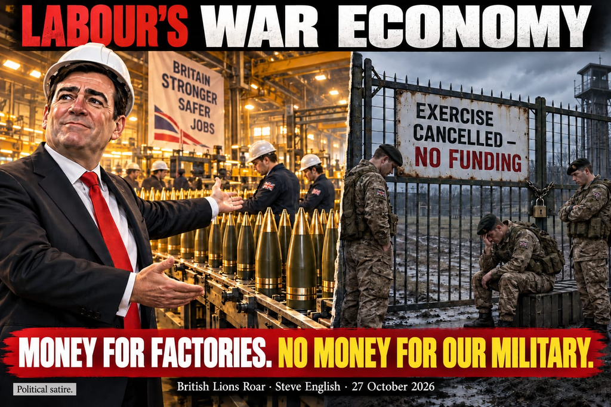

Editorial approach: This article is written in plain English, following George Orwell's rule: if you can say something simply, do so. It combines investigative reporting with policy analysis and opinion. Satire is used where appropriate to test ideas by applying them consistently. Facts are sourced; opinions are labelled; institutions are not indulged.

**DISCLAIMER:** Factual statements in this article are supported by cited sources. Analysis and interpretation are clearly presented as opinion. Nothing published here is intended to incite violence, harassment, or hatred, nor to cause harm. Disagreement with arguments or conclusions does not constitute harm or violence.